# Name: Yuxin Nie

Student number: 22085859

16/12/22

# Originality declaration

I, [**Yuxin Nie**], confirm that the work presented in this assessment is my own. Where information has been derived from other sources, I confirm that this has been indicated in the work.

date: [16/12/22]

# Initial project scope

Report on New York Stop, Question and Frisk in 2021.

## Dataset briefing

- Two datasets will be used in this report. (1) Stop, Question and Frisk data in 2021 (.xlsx file) from NYPD website; (2) Police Precincts shapefile data from NYC Open Data website.
- The .xlsx file contains NYPD Stop Report Database in 2021. First I check this table in Excel and notice there are 83 columns which are collected in categories, including Stop, Question and Frisk (SQF) year/month/time, description of the suspect, whether the suspect was arrested or given an offense, SQF address and location, etc.
- Notice: there are lots of binary columns in the .xlsx file, and if the content is ‘No’, it was documented as ‘(null)’ in this data. However this does not mean the cells are NA values.
- Stop location was collected as X and Y value in the New York-Long Island State Plane Coordinate System (EPSG 2908). Unit of this projection is US survey foot, it is better to transform it into NAD83(2011) / New York Long Island (EPSG:6538) which is in metre unit.

## Research background

- “The stop-question-and-frisk program, or stop-and-frisk, in New York City, is a New York City Police Department practice of temporarily detaining, questioning, and at times searching civilians and suspects on the street for weapons and other contraband.

  In 2016, a reported 12,404 stops were made under the stop-and-frisk program. The stop-and-frisk program has previously taken place on a much wider scale. Between 2003 and 2013, over 100,000 stops were made per year, with 685,724 people being stopped at the height of the program in 2011. At this peak, over 99% of recorded non-lethal interpersonal violence in the city was committed by the New York Police Department itself.

  The program also became the subject of a racial-profiling controversy. Ninety percent of those stopped in 2017 were African-American or Latino, mostly aged 14–24. **Seventy percent of those stopped were later found to be innocent.**” (https://en.wikipedia.org/wiki/Stop-and-frisk_in_New_York_City)

## Research question

- Are innocent people who experienced SQF in 2021 for New York spatially random or do they exhibit clustering?
- Hypothesis: there are spatial clusters for innocent people who experienced SQF in 2021 for New York.

## Research design

- Transform all the SQF data as geographical points.
- And extract points without being arrested nor given summon (define this type of people as ‘innocent’ in this report).
- Then use Ripley’s K and DBSCAN to find the clusters.
- To avoid limitations in DBSCAN, use HDBSCAN for clustering, compare the results and evaluate it.
- Compare location and number of clusters and make suggestions for policy makers.

# Data loading

- load packages

```r
library(sf)
library(sp)
library(tidyverse)
library(tmap)
library(dplyr)
library(stringr)
library(janitor)
library(here)
library(readxl)
```

- Read in ‘sqf-2021.xlsx’ data.

```r
raw_data <- read_excel(here::here('data','sqf-2021.xlsx'),
                       sheet = 1,
                       col_names = TRUE,
                       col_types = NULL,
                       na = "", skip = 0)
```

check the variable type to make sure the type of columns are correct.

```r
datatypelist <- raw_data %>%
  summarise_all(class) %>%
  pivot_longer(everything(),
               names_to = 'All_variables',
               values_to = 'Variable_class')
datatypelist
```

```
## # A tibble: 83 × 2
##    All_variables                Variable_class
##    <chr>                        <chr>
##  1 STOP_ID                      numeric
##  2 STOP_FRISK_DATE              character
##  3 STOP_FRISK_TIME              character
##  4 YEAR2                        numeric
##  5 MONTH2                       character
##  6 DAY2                         character
##  7 STOP_WAS_INITIATED           character
##  8 RECORD_STATUS_CODE           character
##  9 ISSUING_OFFICER_RANK         character
## 10 ISSUING_OFFICER_COMMAND_CODE character
## # … with 73 more rows
```

Some of the numeric columns are now in character type. I will adjust that problem later in data wrangling part if needed.

- Read in shapefile data.

```r
ny <- st_read(here::here('data',
                        'Police Precincts',
                        'geo_export_f486f829-df41-4819-b8e9-f4156793d3e8.shp'))
```

# Data wrangling

## Transforming data

- Project the New York police precincts data to NAD83(2011) / New York Long Island (EPSG:6538) and check after projecting.

```r
ny_proj <- ny %>%
  st_transform(.,6538)
ny_proj #check
```

```
## Simple feature collection with 77 features and 3 fields
## Geometry type: MULTIPOLYGON
## Dimension:     XY
## Bounding box:  xmin: 278336.3 ymin: 36615.2 xmax: 325338.8 ymax: 83163.11
## Projected CRS: NAD83(2011) / New York Long Island
## First 10 features:
##    precinct shape_area shape_leng                       geometry
## 1         1   47286460   80282.64 MULTIPOLYGON (((296291.1 58...
## 2         5   18094527   18807.12 MULTIPOLYGON (((300959.9 61...
## 3         6   22103327   26413.24 MULTIPOLYGON (((300026.7 63...
## 4         7   18366670   17287.54 MULTIPOLYGON (((302242.8 61...
## 5         9   21395386   19772.51 MULTIPOLYGON (((302398.5 62...
## 6        10   27265496   40227.23 MULTIPOLYGON (((299883 6620...
## 7        13   29507656   27719.21 MULTIPOLYGON (((301557.4 64...
## 8        14   20511128   20973.82 MULTIPOLYGON (((302140.9 65...
## 9        17   22268768   26719.68 MULTIPOLYGON (((303022.5 64...
## 10       18   32250244   41625.49 MULTIPOLYGON (((300511.9 67...
```

- Then make the SQF data into spatial data (sf). The original projection is EPSG 2908, I will transform it into 6538 to make sure it is the same as the New York precincts map.

```r
sqf <- raw_data %>%
  st_as_sf(.,coords = c('STOP_LOCATION_X',
                        'STOP_LOCATION_Y'),
           crs = 2908) %>%
  st_transform(.,6538) %>%
  clean_names()
head(sqf) #make a quick check.
```

```
## Simple feature collection with 6 features and 81 fields
## Geometry type: POINT
## Dimension:     XY
## Bounding box:  xmin: 303771.3 ymin: 55666.34 xmax: 320806 ymax: 74061.37
## Projected CRS: NAD83(2011) / New York Long Island
## # A tibble: 6 × 82
##   stop_id stop_fris…¹ stop_…² year2 month2 day2  stop_…³ recor…⁴ issui…⁵ issui…⁶
##     <dbl> <chr>       <chr>   <dbl> <chr>  <chr> <chr>   <chr>   <chr>   <chr>
## 1       1 2021-01-01  01:50:…  2021 Janua… Frid… Based … APP     SGT     042
## 2       2 2021-01-01  10:55:…  2021 Janua… Frid… Based … APP     POM     105
## 3       3 2021-01-01  10:10:…  2021 Janua… Frid… Based … APP     POM     106
## 4       4 2021-01-01  20:17:…  2021 Janua… Frid… Based … APP     POM     083
## 5       5 2021-01-01  19:59:…  2021 Janua… Frid… Based … APP     POM     026
## 6       6 2021-01-01  21:29:…  2021 Janua… Frid… Based … APP     POM     042
## # … with 72 more variables: supervising_officer_rank <chr>,
## #   supervising_officer_command_code <chr>,
## #   supervising_action_corresponding_activity_log_entry_reviewed <chr>,
## #   location_in_out_code <chr>, jurisdiction_code <chr>,
## #   jurisdiction_description <chr>, observed_duration_minutes <dbl>,
## #   suspected_crime_description <chr>, stop_duration_minutes <dbl>,
## #   officer_explained_stop_flag <chr>, …
```

- Make a quick map to make sure everything is alright.

```r
tmap_mode('plot')
```

```
## tmap mode set to plotting
```

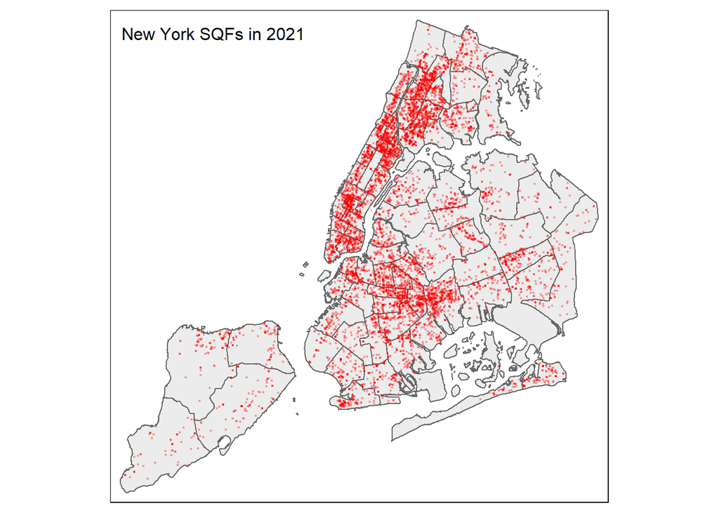

```r
tm_shape(ny_proj)+
  tm_polygons(col = NA, alpha = 0.5)+
  tm_shape(sqf)+
  tm_dots(col = 'red',alpha = 0.2)+
  tm_layout(legend.position = c('left','top'),
            title = 'New York SQFs in 2021',
            title.size =1)
```

## Wrangling data

- Extract data that we need from the sqf dataset. This project focuses on people who are actually innocent after SQF. Thus, I only need columns contain whether the suspect was arrested or given summons.

```r
    sqf2 <- sqf %>%
      dplyr::select('suspect_arrested_flag',
                    'suspect_arrest_offense',
                    'summons_issued_flag',
                    'summons_offense_description',
                    'stop_location_boro_name',
                    'geometry')
```

Select people that were not arrested nor given summons.

```r
    innocent <- sqf2 %>%
      filter(suspect_arrested_flag == 'N') %>%
      filter(summons_issued_flag == 'N')
```

Make a map to check everything is alright.

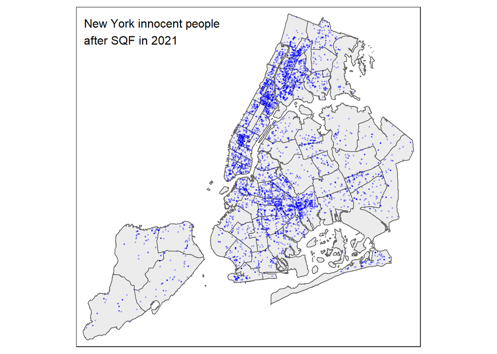

```r
    tm_shape(ny_proj)+
      tm_polygons(col = NA, alpha = 0.5)+
      tm_shape(innocent)+
      tm_dots(col = 'blue',alpha = 0.2)+
      tm_layout(legend.position = c('left','top'),
                title = 'New York innocent people \nafter SQF in 2021',
                title.size =1)
```

## Data subsetting

Now there are 5422 rows of innocent data. Subset data to make sure every point is within New York city.

```r
innocent_sub <- innocent[ny_proj, ,op=st_within]
```

The result shows 6 points are outside of New York city. Excluded them already. Use innocent_sub in the following analysis.

## Preparing data for analysis

- Spatial join two maps.

Join points and polygon to have a look at how many innocent points are in every borough. This result provides a distribution of point counts, which might be helpful for choosing minpts for clustering.

Note: New York map should on the left.

```r
join <- st_join(ny_proj,innocent_sub)
```

- Count by precincts.

Count number of innocent people who experienced SQF, group_by precincts. So we can make a map showing point counts in each precincts.

```r
nygroup <- join %>%
  group_by(.,precinct) %>%
  summarise(total_count=n(),
            .groups = 'drop')
```

- check distributions. check the distributions of point count for different precincts. Grasp the data by knowing its distribution. If there is any outlier, temporarily remove it for better understanding.

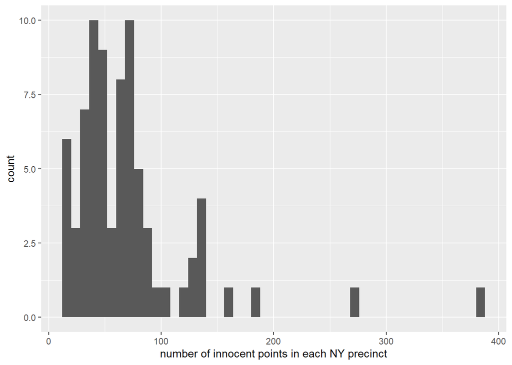

```r
ggplot()+
  geom_histogram(data = nygroup,
                 mapping = aes(x = total_count),
                 binwidth = 8)+
  labs(x = "number of innocent points in each NY precinct",
       y = 'count')
```

This map shows that there are many precincts with a small amount of innocent points while four precincts are far above the others when the number exceeds 150. In this case, it is better to calculate the distribution of data without these four precincts.

```r
group_choose <- nygroup %>%
  filter(.,total_count <150)
summary(group_choose$total_count)
```

```
##    Min. 1st Qu.  Median    Mean 3rd Qu.    Max.
##   12.00   38.00   54.00   60.51   76.00  140.00
```

The statistics show the median number is 54. Plus common sense judgment, if the number of points in one place is greater than 50, it means that this place needs attention in a report.

So, for the following part of analysis, I will use 50 minpts as the start of clustering.

# Spatial pattern analysis.

For clustering, which method we choose depends on what characteristics our data have. In this report, the innocent points are: (1) Arbitrarily shaped clusters; (2) Clusters with different sizes and densities; (3) Noise.

K-means cluster is bad at recognising noise. Also, the irregular shape of New York city means quatrat analysis is not applicable either.

Thus, DBSCAN or HDBSCAN clustering are more appropriate for this report.

```r
library(spatstat)
```

## Create ppp object.

- To create a ppp object, we need a window created by New York boundary.

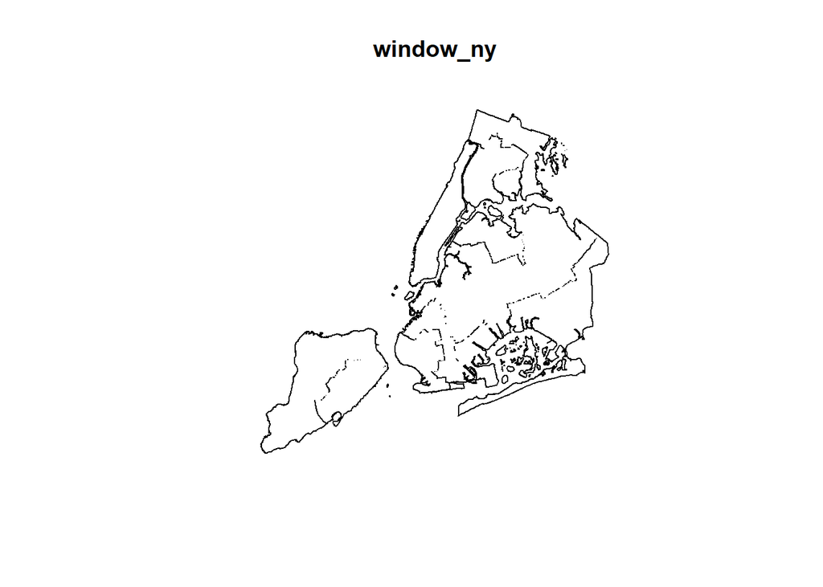

```r
window_ny <- as.owin(ny_proj)
plot(window_ny)
```

- Create sp object and ppp object.

```r
innocent_sp <- innocent_sub %>%
  as(., 'Spatial')
innocent_sp.ppp <- ppp(
  x = innocent_sp@coords[,1],
  y = innocent_sp@coords[,2],
  window = window_ny)
```

- Make a plot to check if ppp object is correct.

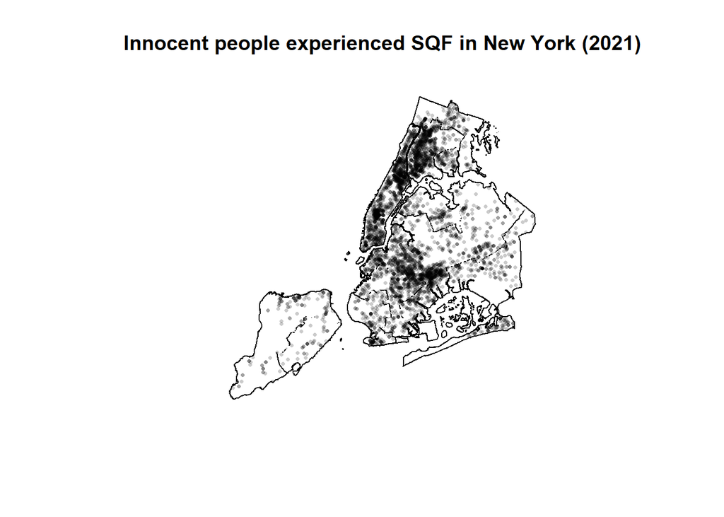

```r
innocent_sp.ppp %>%
  plot(.,pch=16,cex=0.5,
       main="Innocent people experienced SQF in New York (2021)")
```

## Ripley’s K

- Use Ripley’s K to compare the observed distribution of points with the Poisson random model for a whole range of different distance radii.

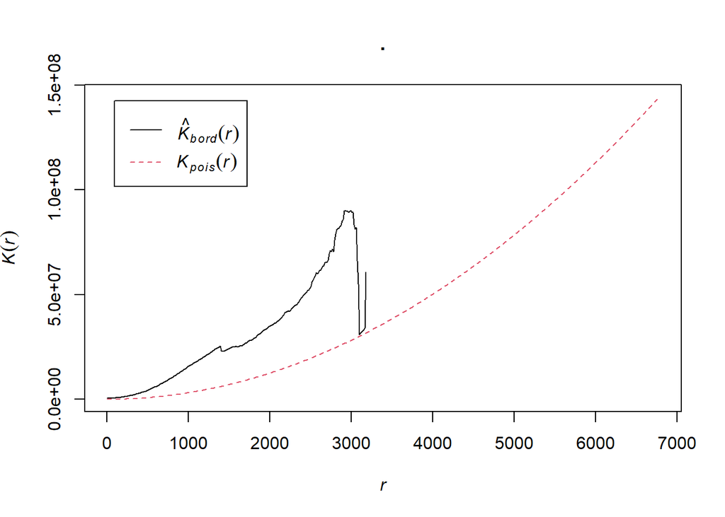

```r
K <- innocent_sp.ppp %>%
  Kest(.,correction = 'border') %>%
  plot()
```

- Black line: observed distribution of points
- Red line: Poisson distribution

The black and red lines nearly intersect. But there is a peak for black line (when r is nearly 3000) and a sharp rise trend before the peak point. The result shows that the innocent points throughout New York can be clustered when the distance radii is less than 3000. This provide a reference for the following epsilon in DBSCAN.

## DBSCAN

```r
library(fpc)
```

- First extract the points from the spatial points data frame

```r
innocent_df <- innocent_sp %>%
  coordinates(.) %>%
  as.data.frame()
```

> Two things are most important for DBSCAN: eps (the maximum distance between two points) and minpts(minimum points)
- From the result of Ripley’s K, I start searching the best eps from 3000, and then decrease the distances according to the cluster result.
- As mentioned above. Choose 50 points as minpts.

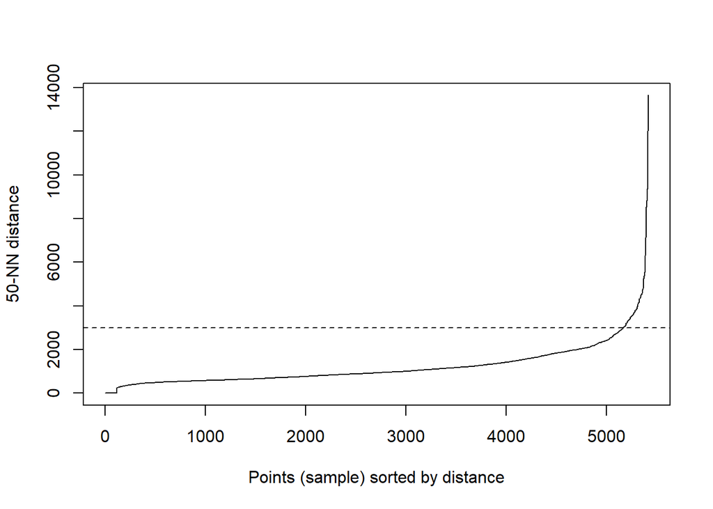

```r
innocent_df%>%
  dbscan::kNNdistplot(.,k=50)
abline(h = 3000, lty = 2) #showing the elbow point in the graph.
```

From the plot above, 3000 again seems like a good distance for clustering.

However, at this distance, nearly everything merges into one cluster, which indicates that eps number should be smaller.

After trying for several numbers, 1000 seems like a good distance for clustering.

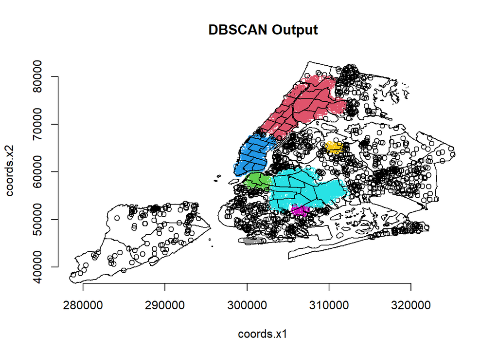

```r
db <- innocent_df %>%
  fpc::dbscan(.,eps =1000, MinPts = 50)
plot(db, innocent_df,
     main = "DBSCAN Output", frame = F)
plot(ny_proj$geometry, add=T)
```

### Mapping DBSCAN result.

- Add the cluster information to the original dataframe.

```r
innocent_df<- innocent_df %>%
  mutate(dbcluster=db$cluster)
```

- Convert the original data frame to a sf object again.

  Cluster value 0 is for the noise points (points in no cluster).Thus, to show all the clusters clearly on map, I have to remove 0 value.

```r
tosf_db <- innocent_df%>%
  st_as_sf(.,
           coords = c("coords.x1", "coords.x2"),
           crs = 6538) %>%
  filter(dbcluster > 0)
```

- use tmap to visualise cluster map.

```r
library(RColorBrewer)
library(tmaptools)
colours<- get_brewer_pal("Set1", n = 9)
```

[figure not shown]

```r
tmap_mode("plot")
```

```
## tmap mode set to plotting
```

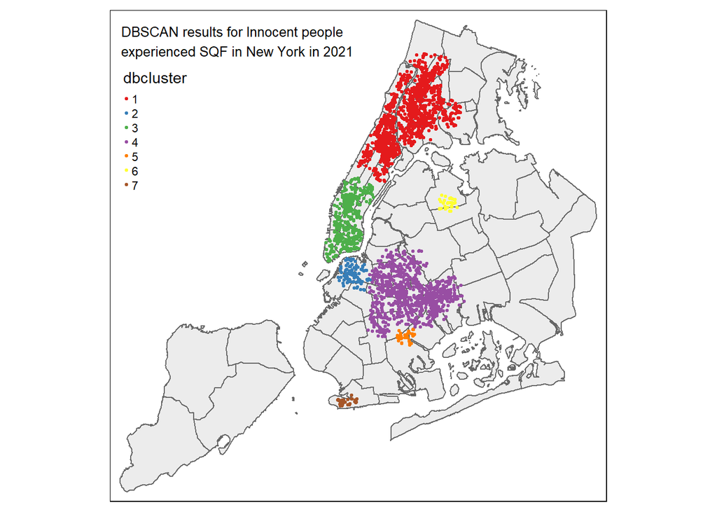

```r
tm_shape(ny_proj) +
  tm_polygons(col = NA, alpha = 0.5) +
tm_shape(tosf_db) +
  tm_dots(col = "dbcluster",
          palette = colours, style = "cat",
          size = 0.05, legend.show = T)+
  tm_layout(legend.position = c('left','top'),
            title = 'DBSCAN results for Innocent people \nexperienced SQF in New York in 2021',
            title.size = .8)
```

The cluster map shows there are 7 clusters for innocent people who experienced Stop, Question and Frisk in New York in 2021. Two huge clusters(cluster 1 and cluster 3) on the north are within Manhattan and Bronx, showing large groups of innocent people experienced SQF in these area. Another huge cluster is at the central of Brooklyn (cluster 4, while other two clusters (cluster 2 and cluster 5) are next to it. Also, there is a small cluster 7 on the far southern side of Brooklyn and another small cluster 6 on the northern side of Queens.

## HDBSCAN

As mentioned above, the eps value I chose is not completely convincing (based on observation of the output). To avoid this problem, it is better to use HDBSCAN, which does not reply on the eps input because it chooses the clusters automatically.

```r
library(dbscan)
HDB <- hdbscan(innocent_df, minPts = 50)
HDB
```

```
## HDBSCAN clustering for 5416 objects.
## Parameters: minPts = 50
## The clustering contains 9 cluster(s) and 1635 noise points.
##
##    0    1    2    3    4    5    6    7    8    9
## 1635   73  101  105  140  104 1566  636   79  977
##
## Available fields: cluster, minPts, coredist, cluster_scores,
##                   membership_prob, outlier_scores, hc
```

HDBSCAN result tells us there are 1635 noise points and 9 clusters when minpts is set to 50. It is noticeable that the cluster 6 and cluster 9 are bigger than other clusters, which might be explored further.

- Plot the hierarchy tree. And show all the clusters.

  “To be able to capture and represent these relationships between clusters, we represent it as a hierarchy tree. This representation generalizes to higher dimensions and is a natural abstraction that is easier to represent as a data structure that we can traverse and manipulate.”

  (https://pberba.github.io/stats/2020/01/17/hdbscan/)

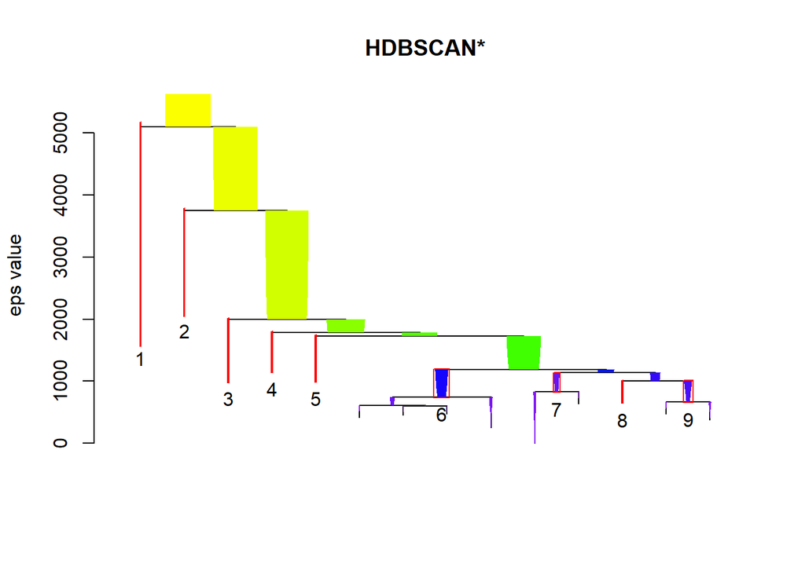

```r
plot(HDB,
     gradient = c("purple", "blue", "green", "yellow"),
     show_flat = T)
```

### Mapping HDBSCAN result

- Add the cluster information to the original dataframe

```r
innocent_df<- innocent_df %>%
  mutate(hdbcluster=HDB$cluster)
```

- Remove 0 value just like what I did above. Same reason.

```r
tosf_hdb <- innocent_df%>%
  st_as_sf(.,
           coords = c("coords.x1", "coords.x2"),
           crs = 6538) %>%
  filter(hdbcluster > 0)
```

- Mapping HDBSCAN and DBSCAN together to make a comparison.

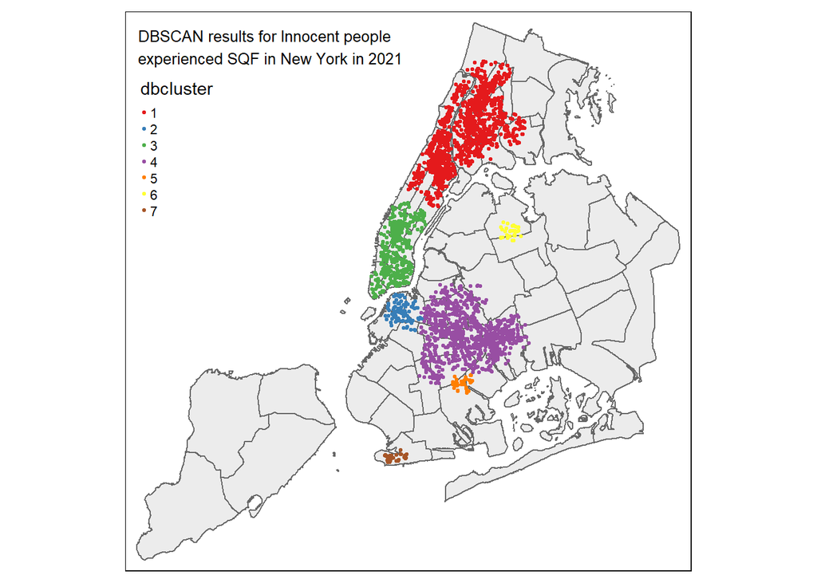

```r
#DBSCAN
tm_shape(ny_proj) +
  tm_polygons(col = NA, alpha = 0.5) +
tm_shape(tosf_db) +
  tm_dots(col = "dbcluster",
          palette = colours, style = "cat",
          size = 0.05, legend.show = T)+
  tm_layout(legend.position = c('left','top'),
            title = 'DBSCAN results for Innocent people \nexperienced SQF in New York in 2021',
            title.size = 0.8)
```

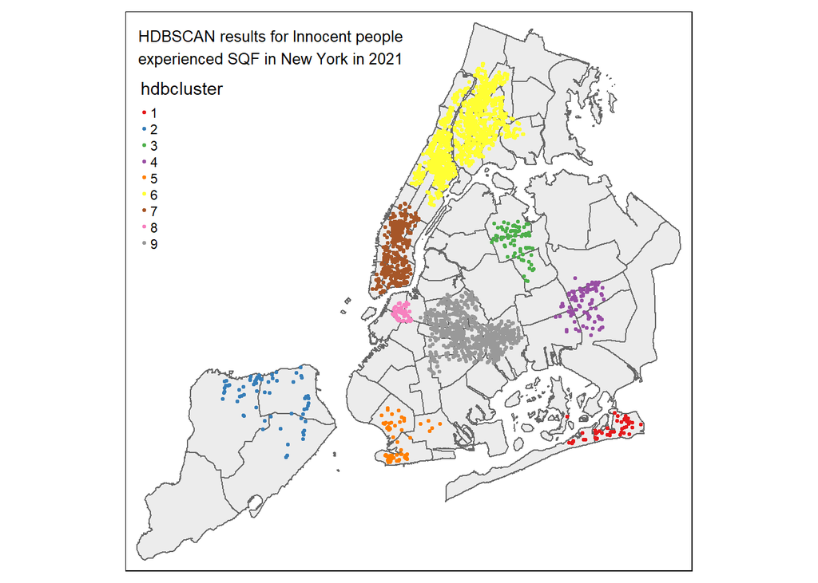

```r
#HDBSCAN
tm_shape(ny_proj) +
  tm_polygons(col = NA, alpha = 0.5) +
tm_shape(tosf_hdb) +
  tm_dots(col = "hdbcluster",
          palette = colours, style = "cat",
          size = 0.05)+
  tm_layout(legend.position = c('left','top'),
            title = 'HDBSCAN results for Innocent people \nexperienced SQF in New York in 2021',
            title.size = 0.8)
```

- Comparison.

HDBSCAN and DBSCAN both show three large clusters in Bronx, Manhattan and central Brooklyn. However, comparing to DBSCAN output, HDBSCAN recognizes more clusters distributed in other boroughs in New York. While in DBSCAN, when the distance becomes smaller, the clusters in the Staten island and Queens area are ignored..

Thus, HDBSCAN presents a more complete picture at the scale of New York City.

# Outputs

## Visualise final map. (HDBSCAN result)

- Make chulls (polygon) for each cluster.

```r
chulls_hdb <- innocent_df %>%
  group_by(hdbcluster) %>%
  dplyr::mutate(hull = 1:n(),
  hull = factor(hull, chull(coords.x1, coords.x2)))%>%
  arrange(hull)
```

- Drop all the noise points (hdbcluster == 0)

```r
chulls_hdb <- chulls_hdb %>%
  filter(hdbcluster >=1)
```

- Visualising it. - There are 3 layers: (1)New York map (2)innocent points (3)cluster polygons. Also, add title and captions.

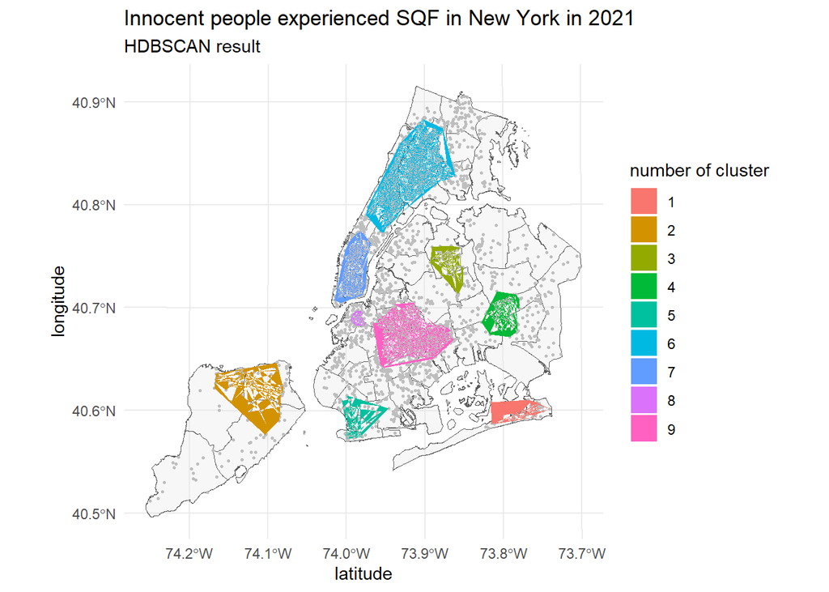

```r
ggplot(data = ny_proj)+
  geom_sf(alpha = 0.3)+
  geom_point(data=innocent_df,
             aes(coords.x1,coords.x2),
             color = 'grey',
             size=0.5,
             alpha = 1)+
  geom_polygon(data = chulls_hdb,
               aes(coords.x1,coords.x2,
                   group=hdbcluster,
                   fill = factor(hdbcluster)),
               alpha = 1,
               show.legend = T)+
  labs(x = 'latitude',
       y = 'longitude',
       title = 'Innocent people experienced SQF in New York in 2021',
       subtitle = 'HDBSCAN result',
       fill = 'number of cluster')+
  theme_minimal()
```

## Interpretation:

- How are the clusters spatially distributed:

The cluster map shows there are 9 clusters for innocent people who experienced Stop, Question and Frisk in New York in 2021.

Two huge clusters(cluster 6 and cluster 7) on the north are within Manhattan and Bronx, showing large groups of innocent people experienced SQF in these area. Another huge cluster is at the central of Brooklyn (cluster 9).

Four smaller clusters (cluster 3,4,5,8) are located surrounding cluster 9. Moreover, two clusters are respectively on the Staten island and the southern island of Queens.

- Why these points exhibit clusters in these areas:

The analysis tells of a spatial clustering of people stopped without actually committing crimes. Manhattan, the bronx and central Brooklyn need to be given special attention as the clusters are much bigger.

Here I put up some possible explanations for this phenomenon. These locations can be highly dangerous and therefore police need to be more rigorous in searching everyone who is suspected. These clusters may be located in central business districts with high population density, high population mobility and high crime rates.

However, if the police acted inappropriately and were too strict about searching people, then the precincts where these clusters are located need to be further examined.

Does race and income or the appearance of the suspect have an impact on whether or not they are stopped and searched. Are there more black or minority ethnic people in these clusters, or do people in these locations have lower income levels? These are some of the things that this report brings to mind.

# Reflection

- Reflections on the methods in this report.
  1. For a better comparasion of the observed distribution of points with the Poisson random mode, I could also try Adjusted Ripley’s
  2. Although I apply HDBSCAN to adjust the results of DBSCAN, there still are a lack of evaluation of the output of HDBSCAN. And this report fails to compare these two clustering model in a more scientific way.
- Reflections on the dataset I use.

  This dataset contains data only for 2021, which means it is quite special, not universal. In particular, 2021 is the second year of the covid pandemic and the epidemic is not completely over, with mutated viruses continuing to be prevalent in this year. Also, this report lacks an analysis of the US political context at this time (US elections). Therefore, it is likely that there are some unusual impacts of this year (for example, covid increased the gap between rich and poor, led to a rise in crime rate in some places).
- Reflections on the research itself.

  This report looks at people who have not committed a crime but have experienced SQF (in this report, described as “innocent”). However, this definition ignores the fact that there are potential suspects (people who are armed but have not yet committed a crime) who may have been alerted to the fact that they have been searched and thus decide not to commit a crime. These people are not technically “innocent”. In future research, further detailed studies on these huge spatial clusters are needed, as well as the exploration of the issue of spatial regression and to mitigate the limitations of this report.